# Geography 176A

Lab 03: Distances, Projections and the Danger Zone

[Catherine Rauch](https://catherinerauch.github.io/geog176A.html)

## In this lab:

##### - building sf objects from R packages and CSVs

##### - manipulating geometries and coordinate systems, calculating distances

##### - building maps using ggplot and accessory packages

##### - examination of a real world application

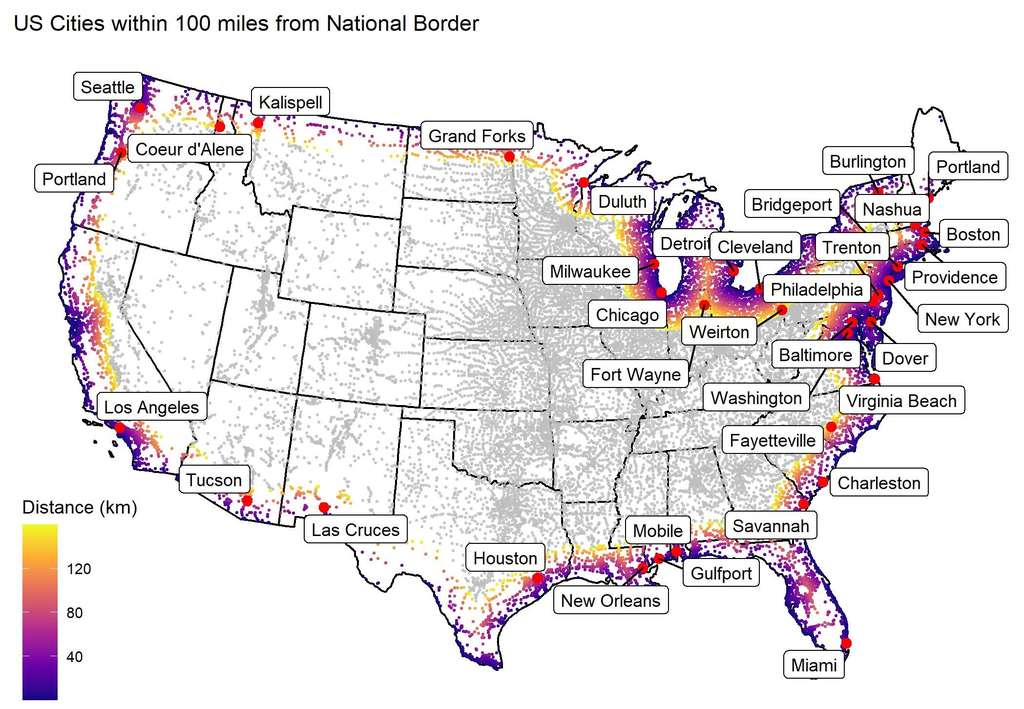

## Data:

##### - spatial boundaries of continental USA states

##### - boundaries of Canada, Mexico and the United States

##### - all USA city

### Libraries

##### data wrangling tools

##### - library(tidyverse)

##### - library(units)

##### spatial objects

##### - library(sf)

##### data used

##### - library(USAboundaries)

##### - library(rnaturalearthdata)

##### plots and tables

##### - library(gghighlight)

##### - library(ggrepel)

##### - library(knitr)

### Creating Data

Because distances between features need to be calculated and used, a projection that perserves distances on a national scale is needed.

Here the North America Equidistant (eqdc) Conic will be used.

- Latitude/Longitude of origin: 40, -96
- Latitude of first/second standard parallel: 20, 60
- False Easting: 0
- False Northing: 0
- Datum: NAD 83
- Units: Meters (m)

```r
# define projection to be used for distance measurements at the national scale
eqdc = '+proj=eqdc +lat_0=40 +lon_0=-96 +lat_1=20 +lat_2=60 +x_0=0 +y_0=0 +datum=NAD83 +units=m +no_defs'
```

##### Get US state boundaries, filter for states in continental United States (conus)

```r
CONUS <- USAboundaries::us_states(resolution = "low") %>%
  filter(!state_name %in% c( "Puerto Rico", "Alaska","Hawaii")) %>%
  st_transform(eqdc)
```

##### Create country boundaries for mexico, USA, canada

```r
countryboundaries <- rnaturalearthdata::countries110 %>%
  st_as_sf(coords = c("lng", "lat"), crs = 4326) %>%
  filter(admin %in% c( "Mexico", "United States of America","Canada") ) %>%
  st_transform(eqdc)
```

##### Retrieve city locations from CSV file, filter for states in conus

```r
citydata <- read_csv("~/github/geog-176A-labs/data/uscities.csv") %>%
  st_as_sf(coords = c("lng", "lat"), crs = 4326) %>%
  st_transform(eqdc) %>%
  filter(!state_name %in% c( "Puerto Rico", "Alaska","Hawaii"))
```

##### Distance to USA Border (coastline or national) (km)

```r
########################################################

# dissolve state boundaries
stCONUS <- st_union(CONUS) %>%
  st_cast("MULTILINESTRING")

citydata = citydata %>%
  mutate(dist_to_border = st_distance(citydata, stCONUS),
         dist_to_border = units::set_units(dist_to_border,"km"),
         dist_to_border = units::drop_units(dist_to_border))

far_cities = citydata %>%
  slice_max(dist_to_border, n = 5) %>%
  data.frame() %>%
  select(city, state_name, dist_to_border)


knitr::kable(far_cities, caption = "Five US Cities Farthest from a National Border",
             col.names = c("City", "State", "Distance from Border (km)"))
```

Five US Cities Farthest from a National Border

| City | State | Distance from Border (km) |
| --- | --- | --- |
| Dresden | Kansas | 1012.317 |
| Herndon | Kansas | 1007.750 |
| Hill City | Kansas | 1005.147 |
| Atwood | Kansas | 1004.734 |
| Jennings | Kansas | 1003.646 |

##### Distance to Individual State Border (km)

```r
########################################################

# keep state boundaries
stCONUSsb <- st_combine(CONUS) %>%
  st_cast("MULTILINESTRING")

citydata = citydata %>%
  mutate(dist_to_state = st_distance(citydata, stCONUSsb),
         dist_to_state = units::set_units(dist_to_state,"km"),
         dist_to_state = units::drop_units(dist_to_state))


farcities = citydata %>%
  slice_max(dist_to_state, n = 5) %>%
  data.frame() %>%
  select(city, state_name, dist_to_state)

knitr::kable(farcities, caption = "Five US Cities Farthest from a State Border",
             col.names = c("City", "State", "Distance from State Border (km)"))
```

Five US Cities Farthest from a State Border

| City | State | Distance from State Border (km) |
| --- | --- | --- |
| Lampasas | Texas | 308.9216 |
| Bertram | Texas | 302.8190 |
| Kempner | Texas | 302.5912 |
| Harker Heights | Texas | 298.8125 |
| Florence | Texas | 298.6804 |

##### Distance to Mexican Border (km)

```r
########################################################

# keep Mexico boundaries
stMexico <- countryboundaries %>%
    filter(admin == "Mexico") %>%
    st_union()

citydata = citydata %>%
  mutate(dist_to_mexico = st_distance(citydata, stMexico),
         dist_to_mexico = units::set_units(dist_to_mexico,"km"),
         dist_to_mexico = units::drop_units(dist_to_mexico))


farMexicocities = citydata %>%
  slice_max(dist_to_mexico, n = 5) %>%
  data.frame() %>%
  select(city, state_name, dist_to_mexico)

knitr::kable(farMexicocities, caption = "Five US Cities Farthest from Mexican Border",
             col.names = c("City", "State", "Distance from Border (km)"))
```

Five US Cities Farthest from Mexican Border

| City | State | Distance from Border (km) |
| --- | --- | --- |
| Caribou | Maine | 3250.334 |
| Presque Isle | Maine | 3234.570 |
| Calais | Maine | 3134.348 |
| Eastport | Maine | 3125.624 |
| Old Town | Maine | 3048.366 |

##### Distance to Canadian Border (km)

```r
########################################################

# keep Canada boundaries
stCanada <- countryboundaries %>%
    filter(admin == "Canada") %>%
    st_union()

citydata = citydata %>%
  mutate(dist_to_canada = st_distance(citydata, stCanada),
         dist_to_canada = units::set_units(dist_to_canada,"km"),
         dist_to_canada = units::drop_units(dist_to_canada))

farCanadacities = citydata %>%
  slice_max(dist_to_canada, n = 5) %>%
  data.frame() %>%
  select(city, state_name, dist_to_canada)

knitr::kable(farCanadacities, caption = "Five US Cities Farthest from Canadian Border",
             col.names = c("City", "State",  "Distance from Border (km)"))
```

Five US Cities Farthest from Canadian Border

| City | State | Distance from Border (km) |
| --- | --- | --- |
| Guadalupe Guerra | Texas | 2206.455 |
| Sandoval | Texas | 2205.641 |
| Fronton | Texas | 2204.784 |
| Fronton Ranchettes | Texas | 2202.118 |
| Evergreen | Texas | 2202.020 |

### Visuliazing the data

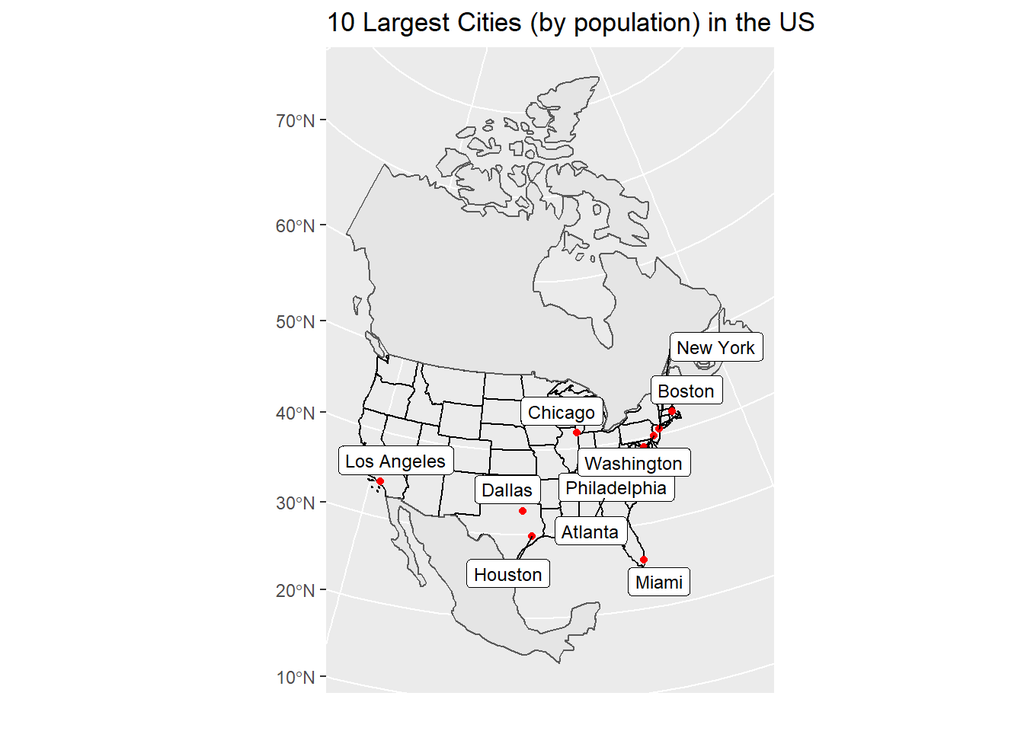

```r
########################################################

largestpop <- citydata %>%
  slice_max(population, n = 10)

# 3 continents, CONUS outline, state boundaries, and 10 largest USA cities (by population)

ggplot() +
  geom_sf(data = stCONUSsb, lty = 1) +
  geom_sf(data = stCanada, lty = 1) +
  geom_sf(data = stMexico, lty = 1) +
  geom_sf(data = largestpop, color = "red") +
  ggrepel::geom_label_repel(
    data = largestpop,
    aes(label = city, geometry = geometry),
    stat = "sf_coordinates",
    size = 3.2) +
  labs(title = "10 Largest Cities (by population) in the US", x = "", y = "")
```

##### Graphing US City Distance from the National Border with 5 farest cities labeled

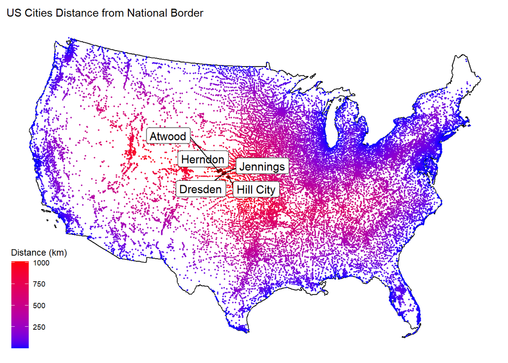

```r
########################################################

far_cities2 = citydata %>%
   slice_max(dist_to_border, n = 5)

ggplot() +
  geom_sf(data = stCONUS, lty = 1, size = .5) +
  geom_sf(data = citydata, aes(col = dist_to_border), size = .3) +
  geom_sf(data = far_cities2, col = "darkred") +
  scale_color_gradient(low = "blue", high = "red") +
  ggthemes::theme_map() +
  ggrepel::geom_label_repel(
    data = far_cities2,
    aes(label = city, geometry = geometry),
    stat = "sf_coordinates",
    size = 4) +
  labs(title = "US Cities Distance from National Border",
       col = "Distance (km)") +  ggthemes::theme_map()
```

##### Graphing US City Distance from the Nearest State Border with 5 farest cities labeled

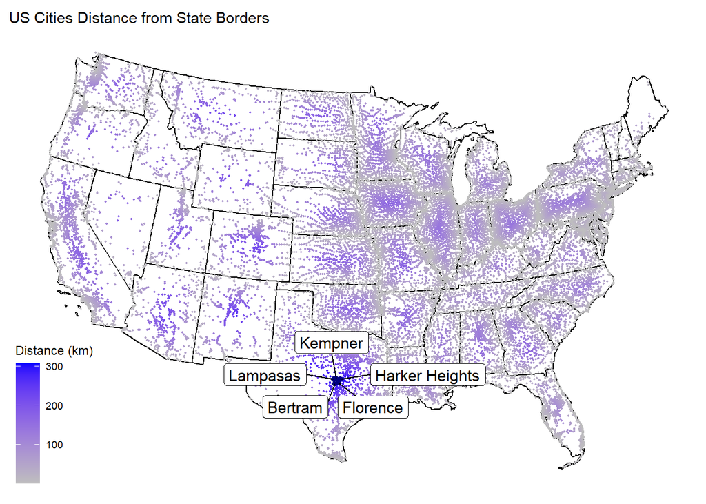

```r
########################################################

farcities2 = citydata %>%
   slice_max(dist_to_state, n = 5)

ggplot() +
  geom_sf(data = stCONUSsb, lty = 1, size = .5) +
  geom_sf(data = citydata, aes(col = dist_to_state), size = .3) +
  geom_sf(data = farcities2, col = "navy") +
  scale_color_gradient(low = "grey", high = "blue") +
  ggthemes::theme_map() +
  ggrepel::geom_label_repel(
    data = farcities2,
    aes(label = city, geometry = geometry),
    stat = "sf_coordinates",
    size = 4) +
  labs(title = "US Cities Distance from State Borders",
       col = "Distance (km)")  +  ggthemes::theme_map()
```

##### Graphing the Equidistance boundary between Mexico and Canada with 5 most populous cites in this zone labeled

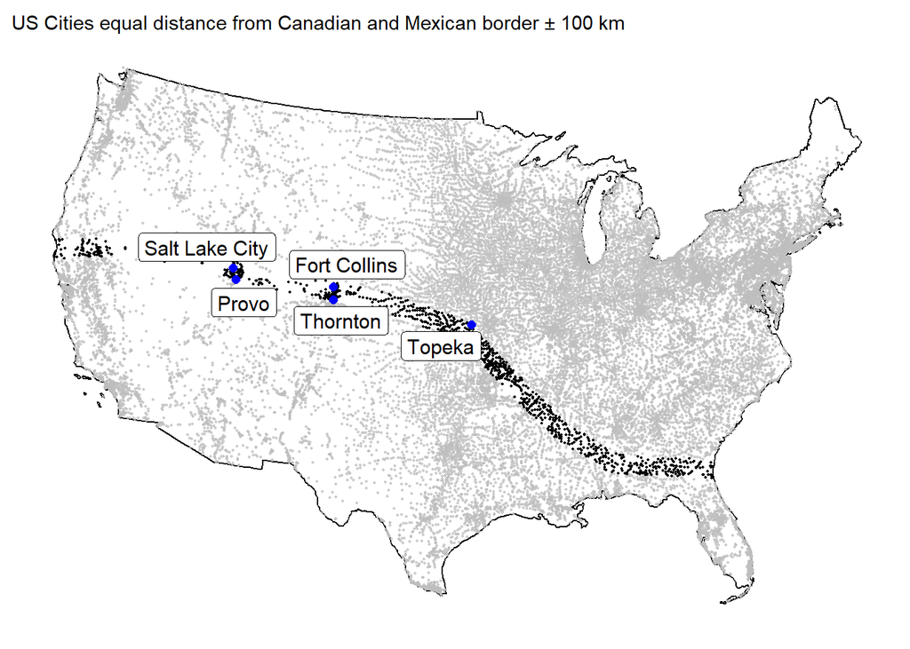

```r
########################################################

citydata <- citydata %>%
  mutate(dist_mexicoandcanada = abs(dist_to_canada - dist_to_mexico),
         dist_mexicoandcanada = units::set_units(dist_mexicoandcanada,"km"),
         dist_mexicoandcanada = units::drop_units(dist_mexicoandcanada))

largestcity = citydata %>%
   filter(dist_mexicoandcanada < 100) %>%
   slice_max(population, n = 5)

ggplot() +
  geom_sf(data = stCONUS, size = .5) +
  geom_sf(data = citydata, size = .3) +
  gghighlight::gghighlight(dist_mexicoandcanada < 100) +
 geom_sf(data = largestcity, col = "blue", size = 2) +
  ggrepel::geom_label_repel(
    data = largestcity,
    aes(label = city, geometry = geometry),
    stat = "sf_coordinates",
    size = 4)  + ggthemes::theme_map() +
  labs(title = "US Cities equal distance from Canadian and Mexican border ± 100 km")
```

### Examining a Real World Problem

Federal Agencies have claimed basic constitutional rights protected by the Fourth Amendment (protecting Americans from random and arbitrary stops and searches) do not apply fully at our borders. Currently, federal regulations give U.S. Customs and Border Protection (CBP) authority to operate within 100 miles of any U.S. “external boundary.” For example, federal authorities do not need a warrant or suspicion of wrongdoing to justify conducting what courts have called a “routine search,” such as searching luggage or a vehicle. More information can be found at this [ACLU article](https://www.aclu.org/other/constitution-100-mile-border-zone).

#### Quantifing and mapping this Danger *(read border)* Zone

How many cities are in this 100 mile zone? How many people live in a city within 100 miles of the border? These questions are addressed as well as, a map highlighting the cites within the 100 mile zone.

```r
########################################################

# how many cities are in this 100 mile zone? (100 miles ~ 160 kilometers)
numcities <- citydata %>%
  filter(dist_to_border < 160) %>%
  nrow()

# how many people live in a city within 100 miles of the border?
numpeople <- citydata %>%
  filter(dist_to_border < 160) %>%
  summarise(sum(population))

# what percentage of the total population is in this zone?
percentpeople <- numpeople / citydata %>%
  summarise(sum(population))

# does it match the ACLU estimate in the link above?
string <- "The ACLU estimates 2 in 3 people (roughly 66.7%) live within the 100 mile border zone, while my estimate was 65.4% roughly a percentage point lower."

########################################################

df <- data.frame(numcities, numpeople$`sum(population)`, 100 * percentpeople$`sum(population)`, string)

kableExtra::kable_styling(knitr::kable(df, col.names = c("Total number of cities within 100 mile zone",
                                                         "Total number of people living within 100 mile zone",
                                                         "Percent of Population living within 100 mile zone",
                                                         ""),
                                       format.args = list(big.mark = ","),  align = "l"))
```

| Total number of cities within 100 mile zone | Total number of people living within 100 mile zone | Percent of Population living within 100 mile zone |  |
| --- | --- | --- | --- |
| 12,283 | 259,935,815 | 65.43979 | The ACLU estimates 2 in 3 people (roughly 66.7%) live within the 100 mile border zone, while my estimate was 65.4% roughly a percentage point lower. |

##### Labeling 10 most populous cities in the Danger Zone

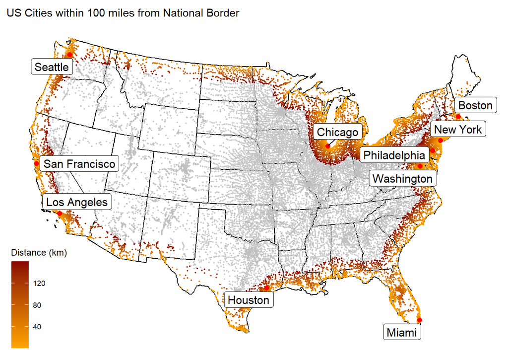

```r
########################################################

# map highlighting cites within the 100 mile zone of border
# label the 10 most populous cities in the Danger Zone

mostpopdanger <- citydata %>%
  filter(dist_to_border < 160) %>%
  slice_max(population, n = 10)

ggplot() +
  geom_sf(data = stCONUSsb, size = .5) +
  geom_sf(data = citydata, aes(col = dist_to_border), size = .3) +
  gghighlight::gghighlight(dist_to_border < 160) +
  scale_color_gradient(low = "orange", high = "darkred") +
  ggthemes::theme_map() +
  geom_sf(data = mostpopdanger, col = "red", size = 2) +
  ggrepel::geom_label_repel(
    data = mostpopdanger,
    aes(label = city, geometry = geometry),
    stat = "sf_coordinates",
    size = 4)  +
  labs(title = "US Cities within 100 miles from National Border",
       col = "Distance (km)")
```

##### Labeling most populous city by state in the Danger Zone

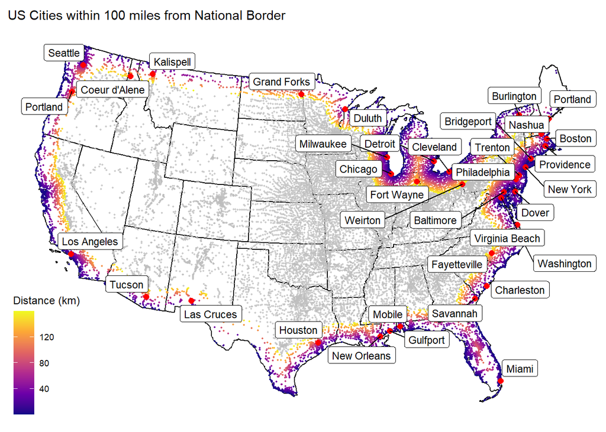

```r
###################################### EXTRA CREDIT

# label the most populous city in each state within the Danger Zone
mostpopdangerbystate <- citydata %>%
  filter(dist_to_border < 160) %>%
  group_by(state_name) %>%
  slice_max(population)

ggplot() +
  geom_sf(data = stCONUSsb, size = .5) +
  geom_sf(data = citydata, aes(col = dist_to_border), size = .3) +
  gghighlight::gghighlight(dist_to_border < 160) +
  scale_color_viridis_c(option = "C") +
  ggthemes::theme_map() +
  geom_sf(data = mostpopdangerbystate, col = "red", size = 2) +
  ggrepel::geom_label_repel(
    data = mostpopdangerbystate,
    aes(label = city, geometry = geometry),
    stat = "sf_coordinates",
    size = 3)  +
  labs(title = "US Cities within 100 miles from National Border",
       col = "Distance (km)")
```

From these maps it can be seen that the Border Patrol’s operations encroach deep into and across the United States, affecting many Americans. States like Connecticut, Delaware, Florida, Hawaii, Maine, Massachusetts, New Hampshire, New Jersey, New York, Rhode Island and Vermont lie entirely or almost entirely within this area. With some of the largest U.S. metropolitan areas (New York City, Los Angeles, Chicago, Philadelphia) falling inside this zone.